**Practical Machine Learning - Course Project**

*Kris Rao*

**Loading and Preprocessing the Data**

```r
library(knitr)
library(caret)
```

```r
library(ggplot2)
pmltrain<-read.csv("C:/Users/kris/Documents/pmltrain.csv")
pmltest<-read.csv("C:/Users/kris/Documents/pmltest.csv")
str(pmltest)
```

```
## 'data.frame':    20 obs. of  160 variables:
##  $ X                       : int  1 2 3 4 5 6 7 8 9 10 ...
##  $ user_name               : Factor w/ 6 levels "adelmo","carlitos",..: 6 5 5 1 4 5 5 5 2 3 ...
##  $ raw_timestamp_part_1    : int  1323095002 1322673067 1322673075 1322832789 1322489635 1322673149 1322673128 1322673076 1323084240 1322837822 ...
##  $ raw_timestamp_part_2    : int  868349 778725 342967 560311 814776 510661 766645 54671 916313 384285 ...
##  $ cvtd_timestamp          : Factor w/ 11 levels "2/12/2011 13:33",..: 11 7 7 1 3 8 8 7 9 2 ...
##  $ new_window              : Factor w/ 1 level "no": 1 1 1 1 1 1 1 1 1 1 ...
##  $ num_window              : int  74 431 439 194 235 504 485 440 323 664 ...
##  $ roll_belt               : num  123 1.02 0.87 125 1.35 -5.92 1.2 0.43 0.93 114 ...
##  $ pitch_belt              : num  27 4.87 1.82 -41.6 3.33 1.59 4.44 4.15 6.72 22.4 ...
##  $ yaw_belt                : num  -4.75 -88.9 -88.5 162 -88.6 -87.7 -87.3 -88.5 -93.7 -13.1 ...
##  $ total_accel_belt        : int  20 4 5 17 3 4 4 4 4 18 ...
##  $ kurtosis_roll_belt      : logi  NA NA NA NA NA NA ...
##  $ kurtosis_picth_belt     : logi  NA NA NA NA NA NA ...
##  $ kurtosis_yaw_belt       : logi  NA NA NA NA NA NA ...
```

[output cut: 86 more lines]

*We notice that many of the variables have all NA values in the test set. We will identify and remove those variables from both the test and training sets as they will not assist in the prediction of values for the test set. This will help from a data compression standpoint.*

```r
pmltest2<-pmltest[,which(unlist(lapply(pmltest, function(x)!all(is.na(x)))))]
pmltrain2<-pmltrain[,which(unlist(lapply(pmltest, function(x)!all(is.na(x)))))]
str(pmltrain2)
```

```
## 'data.frame':    19622 obs. of  60 variables:
##  $ X                   : int  1 2 3 4 5 6 7 8 9 10 ...
##  $ user_name           : Factor w/ 6 levels "adelmo","carlitos",..: 2 2 2 2 2 2 2 2 2 2 ...
##  $ raw_timestamp_part_1: int  1323084231 1323084231 1323084231 1323084232 1323084232 1323084232 1323084232 1323084232 1323084232 1323084232 ...
##  $ raw_timestamp_part_2: int  788290 808298 820366 120339 196328 304277 368296 440390 484323 484434 ...
##  $ cvtd_timestamp      : Factor w/ 20 levels "2/12/2011 13:32",..: 15 15 15 15 15 15 15 15 15 15 ...
##  $ new_window          : Factor w/ 2 levels "no","yes": 1 1 1 1 1 1 1 1 1 1 ...
##  $ num_window          : int  11 11 11 12 12 12 12 12 12 12 ...
##  $ roll_belt           : num  1.41 1.41 1.42 1.48 1.48 1.45 1.42 1.42 1.43 1.45 ...
##  $ pitch_belt          : num  8.07 8.07 8.07 8.05 8.07 8.06 8.09 8.13 8.16 8.17 ...
##  $ yaw_belt            : num  -94.4 -94.4 -94.4 -94.4 -94.4 -94.4 -94.4 -94.4 -94.4 -94.4 ...
##  $ total_accel_belt    : int  3 3 3 3 3 3 3 3 3 3 ...
##  $ gyros_belt_x        : num  0 0.02 0 0.02 0.02 0.02 0.02 0.02 0.02 0.03 ...
##  $ gyros_belt_y        : num  0 0 0 0 0.02 0 0 0 0 0 ...
##  $ gyros_belt_z        : num  -0.02 -0.02 -0.02 -0.03 -0.02 -0.02 -0.02 -0.02 -0.02 0 ...
```

[output cut: 46 more lines]

*We have now reduced to 60 variables with relevant values in the test set, from an initial total of 160.*

*We now want to remove the index variable x, which will not assist us.*

```r
pmltest2<-pmltest2[,-1]
pmltrain2<-pmltrain2[,-1]
```

*Next, we will separate the new truncated training set into a train and test section, so that we can do cross validation on our model down the road.*

```r
set.seed <- 104729
temp <- createDataPartition(y = pmltrain2$classe, p=0.7, list = FALSE)
newtrain <- pmltrain2[ temp,]
newtest  <- pmltrain2[-temp,]
rm(temp)
```

**Building a Model**

*Now we build the model. We will begin by trying a random forest model. We can not use a logistic regression model here without using dummy variables because there are 5 possible outcomes. Random Forest models are very accurate, but run the risk of requiring significant computing time. We will set the mtry variable to 10, meaning that we will try 10 variables selected at random as candidates at each split, in order to reduce computing time.*

```r
modfit<-train(classe ~ ., data = newtrain, method = "rf", tuneGrid=data.frame(mtry=10))
print(modfit$finalModel)
```

```
##
## Call:
##  randomForest(x = x, y = y, mtry = param$mtry)
##                Type of random forest: classification
##                      Number of trees: 500
## No. of variables tried at each split: 10
##
##         OOB estimate of  error rate: 0.1%
## Confusion matrix:
##      A    B    C    D    E  class.error
## A 3904    2    0    0    0 0.0005120328
## B    1 2655    2    0    0 0.0011286682
## C    0    2 2394    0    0 0.0008347245
## D    0    0    3 2248    1 0.0017761989
## E    0    0    0    3 2522 0.0011881188
```

*We now attempt to cross validate our results against our testing set that we retained (note: this is not the overall test set for the problem).*

```r
predtest<-predict(modfit,newdata=newtest)
confusionMatrix(predtest,newtest$classe)
```

```
## Confusion Matrix and Statistics
##
##           Reference
## Prediction    A    B    C    D    E
##          A 1672    0    0    0    0
##          B    2 1139    2    0    0
##          C    0    0 1023    1    0
##          D    0    0    1  962    0
##          E    0    0    0    1 1082
##
## Overall Statistics
##
##                Accuracy : 0.9988
##                  95% CI : (0.9976, 0.9995)
##     No Information Rate : 0.2845
##     P-Value [Acc > NIR] : < 2.2e-16
##
##                   Kappa : 0.9985
##  Mcnemar's Test P-Value : NA
##
## Statistics by Class:
##
##                      Class: A Class: B Class: C Class: D Class: E
## Sensitivity            0.9988   1.0000   0.9971   0.9979   1.0000
## Specificity            1.0000   0.9992   0.9998   0.9998   0.9998
## Pos Pred Value         1.0000   0.9965   0.9990   0.9990   0.9991
## Neg Pred Value         0.9995   1.0000   0.9994   0.9996   1.0000
## Prevalence             0.2845   0.1935   0.1743   0.1638   0.1839
## Detection Rate         0.2841   0.1935   0.1738   0.1635   0.1839
## Detection Prevalence   0.2841   0.1942   0.1740   0.1636   0.1840
## Balanced Accuracy      0.9994   0.9996   0.9984   0.9989   0.9999
```

*We see that our model performed very well on that test set, with accuracy of 99.9%. Let’s examine with a plot where the incorrect values were.*

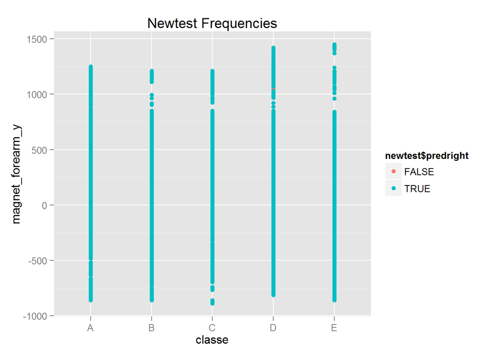

```r
newtest$predright<-predtest==newtest$classe
qplot(classe, magnet_forearm_y,  data=newtest, main="Newtest Frequencies", color=newtest$predright)
```

*Unfortunately, there are so few wrong values, we can’t effectively see them.*

*Because our model appears to be good, let’s apply it to the true test values and get our 20 predicted answers.*

```r
predict(modfit, newdata=pmltest2)
```

```
##  [1] B A B A A E D B A A B C B A E E A B B B
## Levels: A B C D E
```